# Optimal Treatment Analysis

## Outcome Variable

**Outcome Variable:** haz

## Predictor Variables

**Intervention Variable:** predfeed6

**Adjustment Set:**

- arm
- sex
- month
- brthmon
- W_mage
- meducyrs
- feducyrs
- hhwealth_quart
- hfoodsec
- W_mhtcm
- W_mwtkg
- W_mbmi
- vagbrth
- W_gagebrth
- W_birthwt
- W_birthlen
- W_nrooms
- W_nchldlt5
- W_parity
- impfloor
- impsan
- safeh20
- delta_W_mage
- delta_meducyrs
- delta_feducyrs
- delta_hhwealth_quart
- delta_hfoodsec
- delta_W_mhtcm
- delta_W_mwtkg
- delta_W_mbmi
- delta_vagbrth
- delta_W_gagebrth
- delta_W_birthwt
- delta_W_birthlen
- delta_W_nrooms
- delta_W_nchldlt5
- delta_W_parity
- delta_impfloor
- delta_impsan
- delta_safeh20

## Stratifying Variables

The analysis was stratified on these variable(s):

- agecat
- studyid
- country

## Data Summary

| agecat | studyid | country | predfeed6 | n_cell | n |
| --- | --- | --- | --- | --- | --- |
| Birth | EE | PAKISTAN | 1 | 38 | 42 |
| Birth | EE | PAKISTAN | 0 | 4 | 42 |
| Birth | GMS-Nepal | NEPAL | 1 | 419 | 563 |
| Birth | GMS-Nepal | NEPAL | 0 | 144 | 563 |
| Birth | JiVitA-3 | BANGLADESH | 1 | 10466 | 13423 |
| Birth | JiVitA-3 | BANGLADESH | 0 | 2957 | 13423 |
| Birth | JiVitA-4 | BANGLADESH | 1 | 2103 | 2632 |
| Birth | JiVitA-4 | BANGLADESH | 0 | 529 | 2632 |
| Birth | MAL-ED | BANGLADESH | 1 | 72 | 205 |
| Birth | MAL-ED | BANGLADESH | 0 | 133 | 205 |
| Birth | MAL-ED | BRAZIL | 1 | 6 | 60 |
| Birth | MAL-ED | BRAZIL | 0 | 54 | 60 |
| Birth | MAL-ED | INDIA | 1 | 4 | 39 |
| Birth | MAL-ED | INDIA | 0 | 35 | 39 |
| Birth | MAL-ED | NEPAL | 1 | 3 | 24 |
| Birth | MAL-ED | NEPAL | 0 | 21 | 24 |
| Birth | MAL-ED | PERU | 1 | 73 | 213 |
| Birth | MAL-ED | PERU | 0 | 140 | 213 |
| Birth | MAL-ED | SOUTH AFRICA | 1 | 1 | 91 |
| Birth | MAL-ED | SOUTH AFRICA | 0 | 90 | 91 |
| Birth | MAL-ED | TANZANIA, UNITED REPUBLIC OF | 1 | 0 | 113 |
| Birth | MAL-ED | TANZANIA, UNITED REPUBLIC OF | 0 | 113 | 113 |
| 6 months | EE | PAKISTAN | 1 | 43 | 48 |
| 6 months | EE | PAKISTAN | 0 | 5 | 48 |
| 6 months | GMS-Nepal | NEPAL | 1 | 406 | 547 |
| 6 months | GMS-Nepal | NEPAL | 0 | 141 | 547 |
| 6 months | JiVitA-3 | BANGLADESH | 1 | 7644 | 9901 |
| 6 months | JiVitA-3 | BANGLADESH | 0 | 2257 | 9901 |
| 6 months | JiVitA-4 | BANGLADESH | 1 | 3328 | 4272 |
| 6 months | JiVitA-4 | BANGLADESH | 0 | 944 | 4272 |
| 6 months | LCNI-5 | MALAWI | 1 | 47 | 272 |
| 6 months | LCNI-5 | MALAWI | 0 | 225 | 272 |
| 6 months | MAL-ED | BANGLADESH | 1 | 84 | 231 |
| 6 months | MAL-ED | BANGLADESH | 0 | 147 | 231 |
| 6 months | MAL-ED | BRAZIL | 1 | 30 | 209 |
| 6 months | MAL-ED | BRAZIL | 0 | 179 | 209 |
| 6 months | MAL-ED | INDIA | 1 | 11 | 218 |
| 6 months | MAL-ED | INDIA | 0 | 207 | 218 |
| 6 months | MAL-ED | NEPAL | 1 | 12 | 225 |
| 6 months | MAL-ED | NEPAL | 0 | 213 | 225 |
| 6 months | MAL-ED | PERU | 1 | 92 | 271 |
| 6 months | MAL-ED | PERU | 0 | 179 | 271 |
| 6 months | MAL-ED | SOUTH AFRICA | 1 | 3 | 233 |
| 6 months | MAL-ED | SOUTH AFRICA | 0 | 230 | 233 |
| 6 months | MAL-ED | TANZANIA, UNITED REPUBLIC OF | 1 | 1 | 232 |
| 6 months | MAL-ED | TANZANIA, UNITED REPUBLIC OF | 0 | 231 | 232 |
| 6 months | SAS-FoodSuppl | INDIA | 1 | 0 | 168 |
| 6 months | SAS-FoodSuppl | INDIA | 0 | 168 | 168 |
| 24 months | EE | PAKISTAN | 1 | 20 | 23 |
| 24 months | EE | PAKISTAN | 0 | 3 | 23 |
| 24 months | GMS-Nepal | NEPAL | 1 | 356 | 470 |
| 24 months | GMS-Nepal | NEPAL | 0 | 114 | 470 |
| 24 months | JiVitA-3 | BANGLADESH | 1 | 3926 | 5088 |
| 24 months | JiVitA-3 | BANGLADESH | 0 | 1162 | 5088 |
| 24 months | JiVitA-4 | BANGLADESH | 1 | 3292 | 4199 |
| 24 months | JiVitA-4 | BANGLADESH | 0 | 907 | 4199 |
| 24 months | LCNI-5 | MALAWI | 1 | 34 | 189 |
| 24 months | LCNI-5 | MALAWI | 0 | 155 | 189 |
| 24 months | MAL-ED | BANGLADESH | 1 | 76 | 205 |
| 24 months | MAL-ED | BANGLADESH | 0 | 129 | 205 |
| 24 months | MAL-ED | BRAZIL | 1 | 25 | 169 |
| 24 months | MAL-ED | BRAZIL | 0 | 144 | 169 |
| 24 months | MAL-ED | INDIA | 1 | 11 | 209 |
| 24 months | MAL-ED | INDIA | 0 | 198 | 209 |
| 24 months | MAL-ED | NEPAL | 1 | 12 | 219 |
| 24 months | MAL-ED | NEPAL | 0 | 207 | 219 |
| 24 months | MAL-ED | PERU | 1 | 68 | 201 |
| 24 months | MAL-ED | PERU | 0 | 133 | 201 |
| 24 months | MAL-ED | SOUTH AFRICA | 1 | 3 | 216 |
| 24 months | MAL-ED | SOUTH AFRICA | 0 | 213 | 216 |
| 24 months | MAL-ED | TANZANIA, UNITED REPUBLIC OF | 1 | 1 | 202 |
| 24 months | MAL-ED | TANZANIA, UNITED REPUBLIC OF | 0 | 201 | 202 |

The following strata were considered:

- agecat: 24 months, studyid: EE, country: PAKISTAN
- agecat: 24 months, studyid: GMS-Nepal, country: NEPAL
- agecat: 24 months, studyid: JiVitA-3, country: BANGLADESH
- agecat: 24 months, studyid: JiVitA-4, country: BANGLADESH
- agecat: 24 months, studyid: LCNI-5, country: MALAWI
- agecat: 24 months, studyid: MAL-ED, country: BANGLADESH
- agecat: 24 months, studyid: MAL-ED, country: BRAZIL
- agecat: 24 months, studyid: MAL-ED, country: INDIA
- agecat: 24 months, studyid: MAL-ED, country: NEPAL
- agecat: 24 months, studyid: MAL-ED, country: PERU
- agecat: 24 months, studyid: MAL-ED, country: SOUTH AFRICA
- agecat: 24 months, studyid: MAL-ED, country: TANZANIA, UNITED REPUBLIC OF
- agecat: 6 months, studyid: EE, country: PAKISTAN
- agecat: 6 months, studyid: GMS-Nepal, country: NEPAL
- agecat: 6 months, studyid: JiVitA-3, country: BANGLADESH
- agecat: 6 months, studyid: JiVitA-4, country: BANGLADESH
- agecat: 6 months, studyid: LCNI-5, country: MALAWI
- agecat: 6 months, studyid: MAL-ED, country: BANGLADESH
- agecat: 6 months, studyid: MAL-ED, country: BRAZIL
- agecat: 6 months, studyid: MAL-ED, country: INDIA
- agecat: 6 months, studyid: MAL-ED, country: NEPAL
- agecat: 6 months, studyid: MAL-ED, country: PERU
- agecat: 6 months, studyid: MAL-ED, country: SOUTH AFRICA
- agecat: 6 months, studyid: MAL-ED, country: TANZANIA, UNITED REPUBLIC OF
- agecat: 6 months, studyid: SAS-FoodSuppl, country: INDIA
- agecat: Birth, studyid: EE, country: PAKISTAN
- agecat: Birth, studyid: GMS-Nepal, country: NEPAL
- agecat: Birth, studyid: JiVitA-3, country: BANGLADESH
- agecat: Birth, studyid: JiVitA-4, country: BANGLADESH
- agecat: Birth, studyid: MAL-ED, country: BANGLADESH
- agecat: Birth, studyid: MAL-ED, country: BRAZIL
- agecat: Birth, studyid: MAL-ED, country: INDIA
- agecat: Birth, studyid: MAL-ED, country: NEPAL
- agecat: Birth, studyid: MAL-ED, country: PERU
- agecat: Birth, studyid: MAL-ED, country: SOUTH AFRICA
- agecat: Birth, studyid: MAL-ED, country: TANZANIA, UNITED REPUBLIC OF

### Dropped Strata

Some strata were dropped due to rare outcomes:

- agecat: Birth, studyid: EE, country: PAKISTAN
- agecat: Birth, studyid: MAL-ED, country: INDIA
- agecat: Birth, studyid: MAL-ED, country: NEPAL
- agecat: Birth, studyid: MAL-ED, country: SOUTH AFRICA
- agecat: Birth, studyid: MAL-ED, country: TANZANIA, UNITED REPUBLIC OF
- agecat: 6 months, studyid: MAL-ED, country: SOUTH AFRICA
- agecat: 6 months, studyid: MAL-ED, country: TANZANIA, UNITED REPUBLIC OF
- agecat: 6 months, studyid: SAS-FoodSuppl, country: INDIA
- agecat: 24 months, studyid: EE, country: PAKISTAN
- agecat: 24 months, studyid: MAL-ED, country: SOUTH AFRICA
- agecat: 24 months, studyid: MAL-ED, country: TANZANIA, UNITED REPUBLIC OF

## Methods Detail

We’re interested in the causal parameters $E[Y_a]$ for all values of $a \in \mathcal{A}$. These parameters represent the mean outcome if, possibly contrary to fact, we intervened to set all units to have $A=a$. Under the randomization and positivity assumptions, these are identified by the statistical parameters $\psi_a=E_W[E_{Y|A,W}(Y|A=a,W)]$. In addition, we’re interested in the mean of $Y$, $E[Y]$ under no intervention (the observed mean). We will estimate these parameters by using SuperLearner to fit the relevant likelihood factors – $E_{Y|A,W}(Y|A=a,W)$ and $p(A=a|W)$, and then updating our likelihood fit using a joint TMLE.

For unadjusted analyses ($W=\{\}$), initial likelihoods were estimated using Lrnr_glm to estimate the simple $E(Y|A)$ and Lrnr_mean to estimate $p(A)$. For adjusted analyses, a small library containing Lrnr_glmnet, Lrnr_xgboost, and Lrnr_mean was used.

# Results Detail

## Results Plots

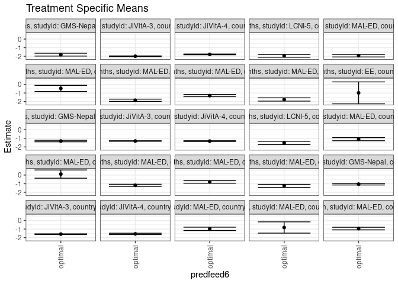

## Results Table

### Parameter: TSM

| agecat | studyid | country | intervention_level | baseline_level | estimate | ci_lower | ci_upper |
| --- | --- | --- | --- | --- | --- | --- | --- |
| Birth | GMS-Nepal | NEPAL | optimal | observed | -1.0515560 | -1.1488920 | -0.9542201 |
| Birth | JiVitA-3 | BANGLADESH | optimal | observed | -1.5932043 | -1.6269547 | -1.5594539 |
| Birth | JiVitA-4 | BANGLADESH | optimal | observed | -1.5646838 | -1.6420182 | -1.4873494 |
| Birth | MAL-ED | BANGLADESH | optimal | observed | -0.9791926 | -1.1719447 | -0.7864405 |
| Birth | MAL-ED | BRAZIL | optimal | observed | -0.8226194 | -1.4780539 | -0.1671849 |
| Birth | MAL-ED | PERU | optimal | observed | -0.9471476 | -1.0998141 | -0.7944812 |
| 6 months | EE | PAKISTAN | optimal | observed | -0.9846021 | -2.2578719 | 0.2886677 |
| 6 months | GMS-Nepal | NEPAL | optimal | observed | -1.3117350 | -1.3983602 | -1.2251098 |
| 6 months | JiVitA-3 | BANGLADESH | optimal | observed | -1.3083962 | -1.3388302 | -1.2779622 |
| 6 months | JiVitA-4 | BANGLADESH | optimal | observed | -1.3194148 | -1.3628568 | -1.2759728 |
| 6 months | LCNI-5 | MALAWI | optimal | observed | -1.5346276 | -1.7283681 | -1.3408871 |
| 6 months | MAL-ED | BANGLADESH | optimal | observed | -1.0961917 | -1.2759615 | -0.9164219 |
| 6 months | MAL-ED | BRAZIL | optimal | observed | 0.1157202 | -0.3618007 | 0.5932411 |
| 6 months | MAL-ED | INDIA | optimal | observed | -1.1899847 | -1.3108555 | -1.0691139 |
| 6 months | MAL-ED | NEPAL | optimal | observed | -0.7981643 | -0.9442819 | -0.6520467 |
| 6 months | MAL-ED | PERU | optimal | observed | -1.2558409 | -1.4324385 | -1.0792433 |
| 24 months | GMS-Nepal | NEPAL | optimal | observed | -1.8092086 | -1.9741675 | -1.6442497 |
| 24 months | JiVitA-3 | BANGLADESH | optimal | observed | -1.9981407 | -2.0386180 | -1.9576634 |
| 24 months | JiVitA-4 | BANGLADESH | optimal | observed | -1.7803460 | -1.8221560 | -1.7385360 |
| 24 months | LCNI-5 | MALAWI | optimal | observed | -1.9510612 | -2.1095782 | -1.7925443 |
| 24 months | MAL-ED | BANGLADESH | optimal | observed | -1.9331598 | -2.0824443 | -1.7838753 |
| 24 months | MAL-ED | BRAZIL | optimal | observed | -0.4669794 | -0.8227789 | -0.1111799 |
| 24 months | MAL-ED | INDIA | optimal | observed | -1.8438621 | -1.9754116 | -1.7123125 |
| 24 months | MAL-ED | NEPAL | optimal | observed | -1.3049895 | -1.4303882 | -1.1795909 |
| 24 months | MAL-ED | PERU | optimal | observed | -1.7507192 | -1.9395785 | -1.5618600 |

### Parameter: E(Y)

| agecat | studyid | country | intervention_level | baseline_level | estimate | ci_lower | ci_upper |
| --- | --- | --- | --- | --- | --- | --- | --- |
| Birth | GMS-Nepal | NEPAL | observed | observed | -1.0641208 | -1.1525364 | -0.9757052 |
| Birth | JiVitA-3 | BANGLADESH | observed | observed | -1.5955338 | -1.6186322 | -1.5724354 |
| Birth | JiVitA-4 | BANGLADESH | observed | observed | -1.5273138 | -1.5765339 | -1.4780937 |
| Birth | MAL-ED | BANGLADESH | observed | observed | -1.0530244 | -1.1913751 | -0.9146736 |
| Birth | MAL-ED | BRAZIL | observed | observed | -0.6963333 | -0.9881882 | -0.4044785 |
| Birth | MAL-ED | PERU | observed | observed | -0.9065728 | -1.0297267 | -0.7834188 |
| 6 months | EE | PAKISTAN | observed | observed | -2.1595486 | -2.5331781 | -1.7859192 |
| 6 months | GMS-Nepal | NEPAL | observed | observed | -1.3540280 | -1.4334801 | -1.2745760 |
| 6 months | JiVitA-3 | BANGLADESH | observed | observed | -1.3138259 | -1.3418712 | -1.2857806 |
| 6 months | JiVitA-4 | BANGLADESH | observed | observed | -1.3482303 | -1.3866421 | -1.3098185 |
| 6 months | LCNI-5 | MALAWI | observed | observed | -1.6395956 | -1.7592633 | -1.5199278 |
| 6 months | MAL-ED | BANGLADESH | observed | observed | -1.1900794 | -1.3096296 | -1.0705291 |
| 6 months | MAL-ED | BRAZIL | observed | observed | 0.0475758 | -0.0963508 | 0.1915023 |
| 6 months | MAL-ED | INDIA | observed | observed | -1.2188303 | -1.3423090 | -1.0953516 |
| 6 months | MAL-ED | NEPAL | observed | observed | -0.5622370 | -0.6774081 | -0.4470660 |
| 6 months | MAL-ED | PERU | observed | observed | -1.3220326 | -1.4308168 | -1.2132484 |
| 24 months | GMS-Nepal | NEPAL | observed | observed | -1.9002128 | -1.9869255 | -1.8135001 |
| 24 months | JiVitA-3 | BANGLADESH | observed | observed | -2.0118003 | -2.0479952 | -1.9756055 |
| 24 months | JiVitA-4 | BANGLADESH | observed | observed | -1.7914765 | -1.8297816 | -1.7531715 |
| 24 months | LCNI-5 | MALAWI | observed | observed | -1.9651323 | -2.1053230 | -1.8249415 |
| 24 months | MAL-ED | BANGLADESH | observed | observed | -1.9576341 | -2.0857597 | -1.8295086 |
| 24 months | MAL-ED | BRAZIL | observed | observed | 0.0061144 | -0.1625850 | 0.1748138 |
| 24 months | MAL-ED | INDIA | observed | observed | -1.8863397 | -2.0168508 | -1.7558287 |
| 24 months | MAL-ED | NEPAL | observed | observed | -1.3187671 | -1.4406685 | -1.1968657 |
| 24 months | MAL-ED | PERU | observed | observed | -1.7524710 | -1.8736426 | -1.6312994 |

### Parameter: PAR

| agecat | studyid | country | intervention_level | baseline_level | estimate | ci_lower | ci_upper |
| --- | --- | --- | --- | --- | --- | --- | --- |
| Birth | GMS-Nepal | NEPAL | optimal | observed | -0.0125647 | -0.0623781 | 0.0372487 |
| Birth | JiVitA-3 | BANGLADESH | optimal | observed | -0.0023295 | -0.0259651 | 0.0213062 |
| Birth | JiVitA-4 | BANGLADESH | optimal | observed | 0.0373700 | -0.0206230 | 0.0953630 |
| Birth | MAL-ED | BANGLADESH | optimal | observed | -0.0738318 | -0.2240746 | 0.0764109 |
| Birth | MAL-ED | BRAZIL | optimal | observed | 0.1262861 | -0.4377273 | 0.6902994 |
| Birth | MAL-ED | PERU | optimal | observed | 0.0405749 | -0.0812046 | 0.1623544 |
| 6 months | EE | PAKISTAN | optimal | observed | -1.1749465 | -2.3980137 | 0.0481207 |
| 6 months | GMS-Nepal | NEPAL | optimal | observed | -0.0422931 | -0.0938815 | 0.0092954 |
| 6 months | JiVitA-3 | BANGLADESH | optimal | observed | -0.0054297 | -0.0173727 | 0.0065133 |
| 6 months | JiVitA-4 | BANGLADESH | optimal | observed | -0.0288155 | -0.0543165 | -0.0033146 |
| 6 months | LCNI-5 | MALAWI | optimal | observed | -0.1049680 | -0.2604700 | 0.0505340 |
| 6 months | MAL-ED | BANGLADESH | optimal | observed | -0.0938876 | -0.2447705 | 0.0569952 |
| 6 months | MAL-ED | BRAZIL | optimal | observed | -0.0681444 | -0.5010127 | 0.3647239 |
| 6 months | MAL-ED | INDIA | optimal | observed | -0.0288456 | -0.0751065 | 0.0174153 |
| 6 months | MAL-ED | NEPAL | optimal | observed | 0.2359273 | 0.1041553 | 0.3676993 |
| 6 months | MAL-ED | PERU | optimal | observed | -0.0661917 | -0.2143221 | 0.0819388 |
| 24 months | GMS-Nepal | NEPAL | optimal | observed | -0.0910042 | -0.2208827 | 0.0388744 |
| 24 months | JiVitA-3 | BANGLADESH | optimal | observed | -0.0136596 | -0.0322438 | 0.0049247 |
| 24 months | JiVitA-4 | BANGLADESH | optimal | observed | -0.0111305 | -0.0290066 | 0.0067455 |
| 24 months | LCNI-5 | MALAWI | optimal | observed | -0.0140710 | -0.0744127 | 0.0462707 |
| 24 months | MAL-ED | BANGLADESH | optimal | observed | -0.0244743 | -0.1321660 | 0.0832173 |
| 24 months | MAL-ED | BRAZIL | optimal | observed | 0.4730938 | 0.1396323 | 0.8065553 |
| 24 months | MAL-ED | INDIA | optimal | observed | -0.0424777 | -0.0808548 | -0.0041005 |
| 24 months | MAL-ED | NEPAL | optimal | observed | -0.0137776 | -0.0428619 | 0.0153067 |
| 24 months | MAL-ED | PERU | optimal | observed | -0.0017517 | -0.1459664 | 0.1424629 |